# ExpressionFilteredHeatmap

Michael K. Jones

2025-08-07

# VastDB Expression filtered Intron Retention Events

## Mask IR events below 25th percentile from data and cluster

```r
library(data.table)
```

```r
library(pheatmap)
library(dplyr)
library(stringr)
library(tidyr)
expressionTable <- fread("/Users/mikej/Documents/Career/Georges/Ule/intron_retention_propensity/data/VastDB/EXPRESSION_TABLE-hg38.tab.gz")
psiTable <- fread("/Users/mikej/Documents/Career/Georges/Ule/intron_retention_propensity/data/VastDB/PSI_TABLE-hg38.tab.gz")
```

## Create table containing only IR events, merge with summary statistics for exploration

```r
psiHsaIN <- psiTable[grep("^HsaIN", psiTable$EVENT), ]
rownames(psiHsaIN) <- psiHsaIN$EVENT
rn <- rownames(psiHsaIN)

# Remove Meta data and Quality measures (-Q$)
metaPsi <- psiHsaIN[, !grepl("-Q$", colnames(psiHsaIN)), with = FALSE]
rownames(metaPsi) <- metaPsi$EVENT

# Create cleaned version of expressionTable
expressionClean <- expressionTable[, !("NAME"), with = FALSE]
expressionClean <- expressionClean[, !grepl("-Counts$", colnames(expressionClean)), with = FALSE]

# Add _PSI suffix to PSI columns
psiColsToRename <- colnames(metaPsi)[7:151]
setnames(metaPsi, psiColsToRename, paste0(psiColsToRename, "_PSI"))

# Clean up input files
rm(psiTable, psiHsaIN, expressionTable)
```

## Old section for adding total library size to annotations

### Identify the count columns

countCols <- grep(“-Counts$”, names(expressionTable), value = TRUE)

### Extract just the count data

countData <- expressionTable[, ..countCols]

### Compute total counts per sample (column-wise sum)

totalCounts <- colSums(countData, na.rm = TRUE)

### Add as new column in tissueAnnotation

tissueAnnotation <- readRDS(“~/Documents/Career/Georges/Ule/intron_retention_propensity/results/tissueAnnotation.rds”) tissueAnnotation2 <- tissueAnnotation tissueAnnotation2$TotalCounts <- totalCounts

### Optional: Save the column annotation object

###saveRDS(tissueAnnotation2, file = “tissueAnnotation2.rds”)

```r
# Determine low-expression events (bottom 25% cRPKM genes set to 0)
exprCols <- grep("-cRPKM$", colnames(expressionClean), value = TRUE)
allExprValues <- unlist(expressionClean[, ..exprCols], use.names = FALSE)
exprThreshold <- quantile(allExprValues[allExprValues > 0], probs = 0.25, na.rm = TRUE)

# Set values below threshold to 0
expressionCleanLowMasked <- copy(expressionClean)
for (col in exprCols) {
  expressionCleanLowMasked[[col]][expressionCleanLowMasked[[col]] <= exprThreshold] <- 0
}
```

## This section imputes missing values and calculates k-means clusters

### Remove first 6 columns (e.g. CLUSTER, GENE, EVENT, COORD, INFO, LENGTH)

cleanPsi <- metaPsi[, -c(1:6), with = FALSE]

### Convert to matrix for imputation and clustering

valuesMatrix <- as.matrix(cleanPsi)

### Preserve rownames (from EVENT)

rownames(valuesMatrix) <- metaPsi$EVENT

### Impute NAs as event median, copy matrix to preserve original NA values

imputeMatrix <- valuesMatrix  
rownames(imputeMatrix) <- rownames(valuesMatrix) for (i in 1:nrow(imputeMatrix)) { row_na <- is.na(imputeMatrix[i, ]) if (any(row_na)) { imputeMatrix[i, row_na] <- median(imputeMatrix[i, ], na.rm = TRUE) } }

### K-means clustering (k = 4) on imputed matrix

set.seed(43) kmeansRes <- kmeans(imputeMatrix, centers = 4) clusterLabels <- data.frame(cluster = factor(paste0(“Cluster_”, kmeansRes$cluster), levels = paste0(“Cluster_”, 1:4))) rownames(clusterLabels) <- rownames(imputeMatrix)

orderedRows <- rownames(clusterLabels)[order(clusterLabels$cluster)] matrixOrdered <- valuesMatrix[orderedRows, ]

## Use Ensembl v88 to match IDs from Expression Table with GRanges

```r
library(rtracklayer)
gtf <- import("/Users/mikej/Documents/Career/Georges/Ule/intron_retention_propensity/data/VastDB/Homo_sapiens.GRCh38.88.gtf.gz")

# Keep only gene-level entries
genes_gtf <- gtf[gtf$type == "gene"]

# Extract coordinates into a data.table
gene_coords <- data.table(
  ID = genes_gtf$gene_id,
  chr = as.character(seqnames(genes_gtf)),
  start = start(genes_gtf),
  end = end(genes_gtf),
  strand = as.character(strand(genes_gtf)),
  gene_name = genes_gtf$gene_name
)

# Merge with your expression data
expressionWithCoords <- merge(expressionCleanLowMasked, gene_coords, by = "ID", all.x = TRUE)
```

```r
# Clean up
rm(expressionClean, expressionCleanLowMasked)
```

```r
library(GenomicRanges)

# Split COORD into chr, start, and end for both data.frames
metaPsi[, c("chr", "start", "end") := tstrsplit(gsub("^chr", "", COORD), "[:-]")]
metaPsi[, `:=`(start = as.integer(start), end = as.integer(end))]
metaPsi[, strand := substr(FullCO, nchar(FullCO), nchar(FullCO))]

# Convert to GRanges
gr_meta <- GRanges(
  seqnames = metaPsi$chr,
  ranges = IRanges(start = metaPsi$start, end = metaPsi$end),
  strand = metaPsi$strand
)

gr_expr <- GRanges(
  seqnames = expressionWithCoords$chr,
  ranges = IRanges(start = expressionWithCoords$start, end = expressionWithCoords$end),
  strand = expressionWithCoords$strand
)

# Carry metadata
mcols(gr_meta) <- metaPsi
mcols(gr_expr) <- expressionWithCoords
```

```r
nearest_hits <- nearest(gr_meta, gr_expr)

# Extract matched metadata
mergedClusterData <- cbind(
  mcols(gr_meta),
  mcols(gr_expr)[nearest_hits, ]
)
```

```r
# Convert from DF to data table
mergedClusterDataDT <- as.data.table(as.data.frame(mergedClusterData))
exprCols <- grep(".cRPKM$", colnames(mergedClusterDataDT), value = TRUE)

# Compute mean cRPKM per row (ignore NA values)
mergedClusterDataDT[, mean_cRPKM := rowMeans(.SD, na.rm = TRUE), .SDcols = exprCols]

# Filter to row with highest mean_cRPKM per EVENT
mergedDataFiltered <- mergedClusterDataDT[mergedClusterDataDT[, .I[which.max(mean_cRPKM)], by = EVENT]$V1]
```

## Match PSI with gene expression using column names

```r
# Extract matched column names
psi_cols <- names(mergedDataFiltered)[7:151]
expr_cols <- names(mergedDataFiltered)[157:301]

# Clean sample names for matching
psi_base <- sub("_PSI$", "", psi_cols)
expr_base <- sub(".cRPKM$", "", expr_cols)

# Find matched column pairs
matched_samples <- intersect(psi_base, expr_base)

# For each matched sample, set PSI to -10 where expression is 0
for (sample in matched_samples) {
  psi_col <- paste0(sample, "_PSI")
  expr_col <- paste0(sample, ".cRPKM")
  mergedDataFiltered[[psi_col]][mergedDataFiltered[[expr_col]] == 0] <- -10
}

#fwrite(mergedCleanedData, file = "mergedRPKMData192951introns.tsv", sep = "\t", quote = FALSE)
```

## Check if any rows have 0 PSI or were filtered by low expression in all samples

```r
# Subset columns 7–151
subset_vals <- mergedDataFiltered[, 7:151]

# Count rows where all values are <= 0 to catch 0 or -10 PSI
count_nonpositive_rows <- sum(rowSums(subset_vals <= 0) == ncol(subset_vals))
count_nonpositive_rows
```

```
## [1] NA
```

## Convert data to matrix for heatmap plotting, load annotations (available on https://github.com/ulelab/intron_retention_propensity/tree/main/results) and build color palettes

```r
# Drop Meta data for heatmap plotting
mergedCleanedData <- mergedDataFiltered
mergedCleanedData <- mergedCleanedData[, -c(1, 3:6, 152:156, 302:307), with = FALSE]
mergedCleanedData <- mergedCleanedData[, !grepl(".cRPKM$", names(mergedCleanedData)), with = FALSE]
mergedCleanedData <- mergedCleanedData %>% filter(!is.na(EVENT))

#fwrite(mergedCleanedData, file = "mergedCleanedData192951introns.tsv", sep = "\t", quote = FALSE)

library(Polychrome)
library(RColorBrewer)

annotation_row <- readRDS("/Users/mikej/Documents/Career/Georges/Ule/intron_retention_propensity/results/annotation_rowsorted12082025.rds")
tissueAnnotation <- readRDS("/Users/mikej/Documents/Career/Georges/Ule/intron_retention_propensity/results/tissueAnnotation2.rds")
tissuePalette <- readRDS("/Users/mikej/Documents/Career/Georges/Ule/intron_retention_propensity/results/tissuePalette.rds")

# Sort matrix based on intron cluster then drop event for heatmap plotting
idx <- match(rownames(annotation_row), mergedCleanedData$EVENT)
mergedCleanedData <- mergedCleanedData[idx, , drop = FALSE]
mergedCleanedData <- as.data.frame(mergedCleanedData)   # preserve rownames behaviour
rownames(mergedCleanedData) <- mergedCleanedData$EVENT
mergedCleanedData$EVENT <- NULL
mergedCleanedMatrix <- as.matrix(mergedCleanedData)

# Replace everything not A/B/C with "Unannotated"
valid <- c("A","B","C")
annotation_row[!(as.character(IntronType) %in% valid), IntronType := "Unannotated"]
annotation_col <- tissueAnnotation[, c("TotalCounts", "Group")]

# Define palettes
clusterPalette <- setNames(RColorBrewer::brewer.pal(5, "Dark2"),
                           levels(annotation_row$Cluster))
intronPalette  <- setNames(c(brewer.pal(3, "Set3"), "grey90"),
                           c("A","B","C","Unannotated"))

# Set row annotations object as data frame
ann_row_df <- as.data.frame(annotation_row[, .(Cluster, IntronType)])
rownames(ann_row_df) <- rownames(annotation_row)

# Bin TotalCounts into 100 equal-width bins
annotation_col$TotalCountsBin <- cut(
  annotation_col$TotalCounts,
  breaks = 100,
  labels = FALSE,
  include.lowest = TRUE
)

# Define a named palette from 1 to 100
totalCountsPalette <- setNames(
  colorRampPalette(c("lightgreen", "darkblue"))(100),
  as.character(1:100)
)

# Heatmap color scale
n_colors <- 100
lowExprSentinel <- -10
colorScale <- c("lightyellow", colorRampPalette(c("lightblue", "dodgerblue", "pink", "firebrick"))(n_colors))
breaks <- c(lowExprSentinel, seq(0, 100, length.out = n_colors + 1))

annotation_colors = list(
  Group = tissuePalette,
  IntronType = intronPalette,
  Cluster = clusterPalette,
  TotalCountsBin = totalCountsPalette
)
```

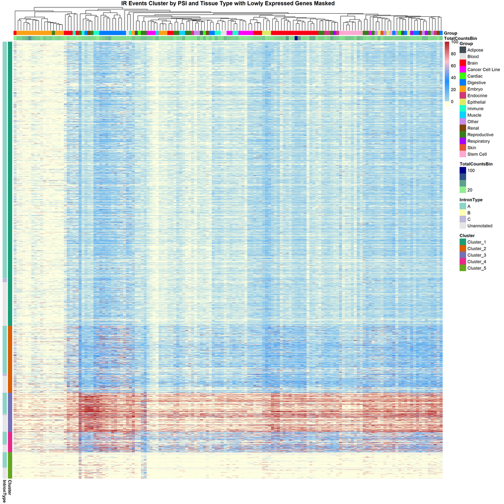

```r
#png("IRHeatmap12082025sorted.png", width = 1600, height = 1600, res = 150)
pheatmap(mergedCleanedMatrix,
         cluster_rows = FALSE,
         cluster_cols = TRUE,
         annotation_row = ann_row_df,
         annotation_col = annotation_col[, c("TotalCountsBin", "Group")],
         annotation_colors = annotation_colors,
         color = colorScale,
         breaks = breaks,
         show_rownames = FALSE,
         show_colnames = FALSE,
         na_col = "grey90",
         main = "IR Events Cluster by PSI and Tissue Type with Lowly Expressed Genes Masked")
```

```r
#dev.off()
```

## Reorder and plot heatmap against intron types from Braunschweig et al 2014

```r
# Drop Meta data for heatmap plotting
mergedCleanedData <- mergedDataFiltered
mergedCleanedData <- mergedCleanedData[, -c(1, 3:6, 152:156, 302:307), with = FALSE]
mergedCleanedData <- mergedCleanedData[, !grepl(".cRPKM$", names(mergedCleanedData)), with = FALSE]
mergedCleanedData <- mergedCleanedData %>% filter(!is.na(EVENT))

annotation_row <- readRDS("/Users/mikej/Documents/Career/Georges/Ule/intron_retention_propensity/results/annotation_rowtype12082025.rds")

# Align matrix rows to the (already sorted) annotation_row
idx <- match(rownames(annotation_row), mergedCleanedData$EVENT)
stopifnot(!any(is.na(idx)))
mergedCleanedData <- as.data.frame(mergedCleanedData[idx, , drop = FALSE])

# Lock rownames from EVENT, then drop EVENT
rownames(mergedCleanedData) <- mergedCleanedData$EVENT
mergedCleanedData$EVENT <- NULL

# Matrix
mergedCleanedMatrix <- as.matrix(mergedCleanedData)

# Row annotations (no reordering, works for data.table or data.frame)
ann_row_df <- as.data.frame(annotation_row[, c("Cluster","IntronType"), drop = FALSE])
rownames(ann_row_df) <- rownames(annotation_row)
```

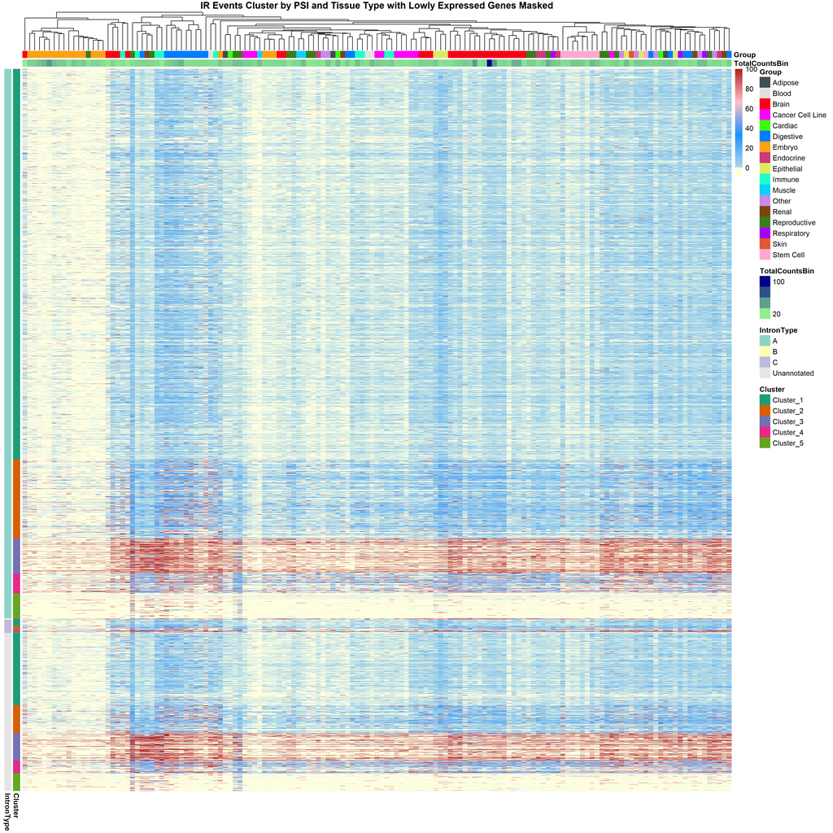

```r
#png("IRHeatmap12082025typesort.png", width = 1600, height = 1600, res = 150)
pheatmap(mergedCleanedMatrix,
         cluster_rows = FALSE,
         cluster_cols = TRUE,
         annotation_row = ann_row_df,
         annotation_col = annotation_col[, c("TotalCountsBin", "Group")],
         annotation_colors = annotation_colors,
         color = colorScale,
         breaks = breaks,
         show_rownames = FALSE,
         show_colnames = FALSE,
         na_col = "grey90",
         main = "IR Events Cluster by PSI and Tissue Type with Lowly Expressed Genes Masked")
```

```r
#dev.off()
```

## Overlap all annotations to export dataset, many annotations were overlapped in other markdown files listed here, source files available on github at https://github.com/ulelab/intron_retention_propensity/tree/main/results

1. PRPF8 prediction sums ~/data/IR/pred_sums.tsv

1. ```
    Merge using rbpnet_predict.ipynb
   ```

2. Minor intron annotations overlap ~/intron_retention_propensity/data/IR/Homo_sapiens_intron.csv

1. ```
    Merge with AnnotationsExplorationMinorSplice.Rmd
   ```

3. Transposable elements overlap ~/intron_retention_propensity/data/IR/hg38.fa.out.gz
1. Merge with AnnotationsPart2transposon.Rmd
4. Decoy splice sites and splice sites only predictions
1. Merged using AnnotationsPart3StatisticsandRegression.Rmd

### High confidence decoys and non-PRPF8 splice sites reflect higher precision and lower sensitivity

```r
final  <- fread("/Users/mikej/Documents/Career/Georges/Ule/intron_retention_propensity/data/VastDB/mergedPredictions192951introns.tsv")
annotation_row <- readRDS("/Users/mikej/Documents/Career/Georges/Ule/intron_retention_propensity/results/annotation_rowsorted12082025.rds")

annotation_row[, EVENT := rownames(annotation_row)]
merged_df <- dplyr::left_join(final, annotation_row, by = "EVENT")
merged_df <- merged_df %>%
  relocate(Cluster, IntronType, .after = 1)

colnames(merged_df)[4] <- "DecoySiteModerateConf"
colnames(merged_df)[5] <- "DecoySiteHighConf"
colnames(merged_df)[6] <- "NonPRPF8SpliceCountHighConf"
colnames(merged_df)[7] <- "NonPRPF8SpliceSignalHighConf"
colnames(merged_df)[8] <- "NonPRPF8SpliceCountModerateConf"
colnames(merged_df)[9] <- "NonPRPF8SpliceSignalModerateConf"

write.table(
  merged_df,
  file = "IntronRetentionPredictionsAnnotated13082025.tsv",
  sep = "\t",
  quote = FALSE,
  row.names = FALSE,
)
```

# OLD SECTION FOR CREATING ANNOTATION OBJECTS

### Define tissue colour palette

groupLevels <- levels(tissueAnnotation2$Group) library(Polychrome) tissuePalette <- Polychrome::createPalette(length(groupLevels), seedcolors = c(“#000000”, “#FFFFFF”)) names(tissuePalette) <- groupLevels

library(readr) ### Create a new annotation for rows with Braunschweig intron types mergedPSI_best_match_subset <- read_tsv(“/Users/mikej/Documents/Career/Georges/Ule/intron_retention_propensity/data/IR/mergedPSI_best_match_subset.tsv”)

### Extract last field after last colon (1-2 characters at end)

mergedPSI_best_match_subset <- mergedPSI_best_match_subset %>% mutate(annotation = str_extract(braun_name, “[^:]+$”))

rowBraunAnnotOrdered <- data.frame( EVENT = mergedPSI_best_match_subset$EVENT, annotation = mergedPSI_best_match_subset$annotation )

### Reorder to match mergedCleanedData rownames (assuming rownames are EVENT IDs)

rowBraunAnnotOrdered <- rowBraunAnnotOrdered %>% filter(EVENT %in% rownames(mergedCleanedData)) %>% arrange(factor(EVENT, levels = rownames(mergedCleanedData))) %>% select(annotation)

### Set rownames to match mergedCleanedData

rownames(rowBraunAnnotOrdered) <- rownames(mergedCleanedData) annotation_row <- cbind(rowAnnotOrdered, rowBraunAnnotOrdered)

### Extract totalCounts and match rownames

totalCountsAnnot <- data.frame(totalCounts = mergedClusterData$totalCounts) rownames(totalCountsAnnot) <- rownames(mergedCleanedData)

### Combine all row annotations together

annotation_row <- cbind(annotation_row, totalCountsAnnot) colnames(annotation_row) <- c(“Cluster”, “IntronType”, “TotalCounts”)

library(RColorBrewer) ### Assign annotation color palettes for intron type intronTypes <- unique(annotation_row$IntronType) intronPalette <- setNames(brewer.pal(length(intronTypes), “Set3”), intronTypes)

### For cluster

clusterPalette <- setNames(brewer.pal(4, “Dark2”), paste0(“Cluster_”, 1:4))

### For totalCounts, use a continuous scale

totalCountsPalette <- colorRampPalette(c(“lightgreen”, “darkgreen”))(100)

### Set heatmap colors and breaks

n_colors <- 100 lowExprSentinel <- -10 colorScale <- c(“lightyellow”, colorRampPalette(c(“lightblue”, “dodgerblue”, “pink”, “firebrick”))(n_colors)) breaks <- c(lowExprSentinel, seq(0, 100, length.out = n_colors + 1))

### Plot heatmap

png(“IRHeatmap19062025.png”, width = 1600, height = 1200, res = 150) pheatmap(matrixOrdered, cluster_rows = FALSE, cluster_cols = TRUE, annotation_row = annotation_row[, c(“Cluster”, “IntronType”, “TotalCounts”)], annotation_col = tissueAnnotation, annotation_colors = list( Group = tissuePalette, IntronType = intronPalette, Cluster = clusterPalette, TotalCounts = totalCountsPalette ), color = colorScale, breaks = breaks, show_rownames = FALSE, show_colnames = FALSE, na_col = “grey90”, main = “Intron Retention Clusters with Sample Groups (Low Expression in Yellow)”) dev.off()

### Save essential objects to RDS

saveRDS(matrixOrdered, “matrixOrdered.rds”) saveRDS(annotation_row, “annotation_row.rds”) saveRDS(tissueAnnotation, “tissueAnnotation.rds”) saveRDS(tissuePalette, “tissuePalette.rds”)